# Data set Pathway and Network Analysis

DNA methylation in neurons from post-mortem brains in schizophrenia and bipolar disorder

Angela Uzelac

2023-04-18

# Introduction

A dopamine imbalance in the human brain is one of the factors central to the pathogenesis of major psychosis. A study done by Pai et al. suggests that epigenetic changes may increase dopamine synthesis and result in psychotic symptoms. Psychosis is a typical symptom observed in patients with Schizophrenia and Bipolar disease. Furthermore, abnormal DNA methylation has been detected in patients with Schizophrenia and bipolar disorder. One of the important experiments performed in this paper was profiling the transcriptomes of neuronal nuclei samples from post-mortem frontal cortex of individuals diagnosed with Schizophrenia and Bipolar disease, as well as controls. Sequencing was done using High-throughput RNASeq. The purpose of this experiment was to determine the consequences of altered DNA methylation in major psychosis (Pai et al. 2019).

In the two previous studies, a dataset was chosen and the raw mRNA expression data was gathered from GEO (Barrett et al. 2012), cleaned up, normalized, and the gene identifiers were converted to HUGO symbols. The duplicate genes and genes with low counts were eliminated, then the data was normalized to account for technical variation. Next, significantly differentially expressed genes were identified from the set obtained in the first study, and a thresholded over-representation analysis was performed in order to determine the prominent themes in the gene set. The main themes discovered in this analysis were circadian rhythm, activation of complement pathway, synapse pruning, and neuronal development.

In the following study, a non-thresholded gene set enrichment analysis was performed to account for the genes that may be part of important pathways but not significantly differentially expressed. First, the genes were ranked from upregulated to downregulated, then an enrichment analysis was performed, and finally, the enrichment results were visualized and presented.

Chosen GEO dataset: GSE112523

Associated paper: [Differential methylation of enhancer at IGF2 is associated with abnormal dopamine synthesis in major psychosis](https://www.ncbi.nlm.nih.gov/pmc/articles/PMC6499808/)

# Procedure and Results

## Non-thresholded Gene set Enrichment Analysis

To prepare for this analysis, in the previous work, a matrix was created containing the expression values of all the genes for control and Schizophrenia samples. Then, the Quasi-Likelihood method was used to calculated differential expression, and the gene list was sorted by p-value (most to least differentially expressed). This matrix was converted back to a dataframe to contain the Ensembl ID and gene name. This dataframe was saved to a file called qlf_output_hits_withgn.tsv, so, the first step was retrieving this table.

```r
qlf_output_hits_withgn <- read.table(file=file.path("./qlf_output_hits_withgn.tsv"),
                                    header = TRUE,sep = "\t",
                                    stringsAsFactors = FALSE,
                                    check.names=FALSE)
```

```r
qlf_output_hits_withgn[,"rank"] <-
  -log(qlf_output_hits_withgn$PValue,base =10) * sign(qlf_output_hits_withgn$logFC)

qlf_output_hits_withgn <- qlf_output_hits_withgn[order(qlf_output_hits_withgn$rank),]

rank_df <- data.frame(genename = qlf_output_hits_withgn$hgnc_symbol, F_stat = qlf_output_hits_withgn$rank)

ranked_genelist_filename <- "ranked_genelist.rnk"

write.table(rank_df,
            file= ranked_genelist_filename,sep = "\t",
            row.names = FALSE,col.names = FALSE,quote = FALSE)
```

```r
head(rank_df)
```

```
##   genename    F_stat
## 1      ARC -2.758013
## 2     EGR1 -2.643772
## 3    NR4A1 -2.549732
## 4  TAMALIN -2.096506
## 5     IER2 -2.020132
## 6     JUND -1.902450
```

```r
tail(rank_df)
```

```
##       genename   F_stat
## 16234   CREBL2 2.222899
## 16235    BNIP3 2.255166
## 16236 SIGLEC10 2.330640
## 16237   CGGBP1 2.457246
## 16238     DCP2 2.478331
## 16239     NSA2 2.779946
```

### What method of Non-thresholded Gene set Enrichment Analysis was used? What genesets were used?

The GSEA software (version 4.3.2) was chosen as the non-thresholded analysis method because it is very popular and has an interface that is easy to use, with no programming knowledge required. Given an a priori defined set of genes that share the same GO category or are part of the same pathway, the goal of GSEA is to determine whether the genes in this set are randomly distributed throughout the inputted ranked list, or if they are primarily found at the top or bottom (Subramanian et al. 2005).

Although there exists a resource, MSigDB, with many annotated gene sets for use in GSEA, for this analysis gene sets were pulled from the [Bader Lab geneset collection](http://download.baderlab.org/EM_Genesets/) instead (Reimand et al. 2019). The Bader Lab genesets get data from many different sources, such as GO, MSigDB, and Reactome. Since GO annotations are updated monthly, these genesets are also compiled on a monthly basis to have the most up to date annotations. In summation, the geneset used in this analysis was downloaded from the Bader lab collection because it contains more pathways, it is more robust, it is updated frequently, and it compiles the geneset into a GMT file, which is the format required for the GSEA software.

Within the Bader Lab collection, the following gene set was chosen (Reimand et al. 2019) (Human, no IEA from April 2, 2023):

- Human gene set because this study looks at only human genes.
- Gene symbol so that it matches with the HGNC symbols used in the data of this study.
- The most recent release of the gene set in order to have the most up to date annotations.
- GO biological process because pathway annotations are of interest (molecular function and cellular component gene sets would not have information on pathways).
- No IEA in order to get the best quality, curated data.

Using the RCurl package (Temple Lang 2021), the following code was run to retrieve the desired gene set, and the file was saved for use in the GSEA analysis.

```r
if (!require("RCurl", quietly = TRUE)){
  install.packages("RCurl")
}
library("RCurl")

gmt_url = "http://download.baderlab.org/EM_Genesets/current_release/Human/symbol/"
# list all the files on the server
filenames = RCurl::getURL(gmt_url)
tc = textConnection(filenames)
contents = readLines(tc)
close(tc)
# get the gmt that has all the pathways and does not include terms inferred
# from electronic annotations(IEA) start with gmt file that has pathways only
rx = gregexpr("(?<=<a href=\")(.*.GOBP_AllPathways_no_GO_iea.*.)(.gmt)(?=\">)", contents, perl = TRUE)
gmt_file = unlist(regmatches(contents, rx))
```

```r
dest_gmt_file <- file.path("./", gmt_file)
download.file(paste(gmt_url, gmt_file, sep = ""), destfile = dest_gmt_file)
```

Name of GMT file: Human_GOBP_AllPathways_no_GO_iea_April_02_2023_symbol.gmt

Name of ranked gene list file: ranked_genelist.rnk

To perform the non-thresholded gene set enrichment analysis, first, the GSEA desktop application was opened and “Run GSEA Preranked” was clicked. A preranked analysis was done because GSEA is designed for microarray data, whereas edgeR is optimized for RNASeq data. Therefore, it is preferred to use the ranked file created in the previous analysis because it provides a much more accurate ranking. Since a pre-ranked list is input to GSEA, it is not desirable that the phenotypes are shuffled, instead the gene set is permutated.

Next, the “Load Data” tab was clicked in the left navigation bar. Files Human_GOBP_AllPathways_no_GO_iea_April_02_2023_symbol.gmt and ranked_genelist.rnk were loaded. Human_GOBP_AllPathways_no_GO_iea_April_02_2023_symbol.gmt was chosen as the “Gene sets database,” and ranked_genelist.rnk was chosen as the “Ranked List.” The “Collapse/Remap to gene symbols” parameter was selected to be No_Collapse because the gene list contains symbols that matches the gene set database. The maximum gene set size was decreased to 200 because some of the pathways are very large and do not provide much information when it comes to annotations. Instead, smaller gene sets are desired because they give more specific and meaningful results. All other parameters remained as default. Finally, GSEA was run.

### Summary of Enrichment Results. How do these results compare to the results from the thresholded analysis. Is this a straight forward comparison? Why or why not?

A summary of the results is displayed below.

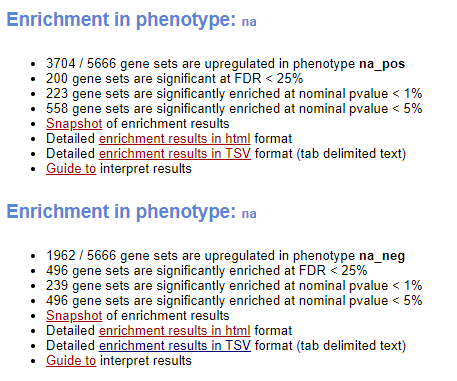

Figure 2. Summary of GSEA results. The na_pos phenotype represents the upregulated or top-ranking genes, and the na_neg phenotype is the downregulated or bottom-ranking genes.

Since gene set sizes from 15 to 200 were used, this resulted in 5666 gene sets being included in the analysis. Out of these 5666 gene sets, approximately 65% are upregulated in the disease phenotype. The results also show that the proportion of gene sets enriched with a false discovery rate of less than 0.25 was much higher for the downregulated phenotype. Also, the proportion of gene sets significantly enriched at p-value less than 0.05 was higher in downregulated phenotype.

Some of the top terms for genes that are upregulated in Schizophrenia were “TYROBP CAUSAL NETWORK IN MICROGLIA,” “RHO GTPASES ACTIVATE WASPS AND WAVES,” and “REGULATION OF PHAGOCYTOSIS.” The top terms for genes that are downregulated in disease were “COLLAGEN CHAIN TRIMERIZATION,” “ASSEMBLY OF COLLAGEN FIBRILS AND OTHER MULTIMERIC STRUCTURES,” and “SYNAPTIC_VESICLE_TRAFFICKING.” These terms are obviously different from the results obtained in the thresholded enrichment analysis. There may be terms that are similar and referring to the same pathways, but this is not a straightforward comparison. Firstly, the terms used in the different annotation sources like GO biological process, Reactome, and WikiPathways are not always the same. Second, these terms may be either more or less specific than the terms seen in the G:profiler results. Another reason might be because even if they had some of the same terms, they may have a different number of genes associated with the gene set, putting the gene set at a different spot in the results. Therefore, it would be difficult to come up with a way to do a one-to-one comparison of the terms. Although, there are some terms that were observed to be similar in the GSEA and G:profiler analysis such as terms relating to synapses, exocytosis, and neuronal cells.

## Visualizing the Gene set Enrichment Analysis in Cytoscape

To visualize the gene set enrichment analysis, the Cytoscape software (version 3.8.2) was used (Shannon et al. 2003). First, the Cytoscape desktop application was opened, then the EnrichmentMap Pipeline Collection was downloaded for use of apps like EnrichmentMap, WordCloud, and AutoAnnotate (Reimand et al. 2019). The EnrichmentMap app was then opened, and the resulting folder from the GSEA analysis was chosen as input. The software automatically loaded the appropriate report files for the na_pos phenotype, na_neg phenotype, the filtered GMT file containing only the genes found in the expression file provided to GSEA, and the ranked gene list. Additionally, the positive phenotype was named “Upregulated” and the negative phenotype was named “Downregulated.”

### What thresholds were used to create this map?

The following parameters were chosen for the map (Reimand et al. 2019):

- “Filter genes by expression” was checked in order to exclude genes that are in the GMT file but not found in the expression file, otherwise, genes that are not part of the expression data would undesirably show up in the heatmap
- the FDR q-value cutoff was set to 0.05 because this is the commonly accepted significance cutoff
- the p-value cutoff was kept at the default of 1.0
- the connectivity was left in the middle of sparse and dense
  - This metric determines if two gene sets (nodes) are connected based on their similarity, i.e. how many gene they have in common. When the connectivity is directly in the middle, it means that the Jaccard coefficient and the Overlap are weighted at 50% each. Additionally, the edge cutoff was left at 0.375, meaning that 37.5% of the genes are shared between the two nodes.

### How many nodes and how many edges are in the enrichment map?

Number of nodes in the enrichment map: 67

Number of edges in the enrichment map: 89

There are not too many nodes and the nodes are not overly interconnected, therefore the Q-value and similarity thresholds were not changed.

The initial network created in Cytoscape, before any adjustments, can be seen in the Figure 3 below.

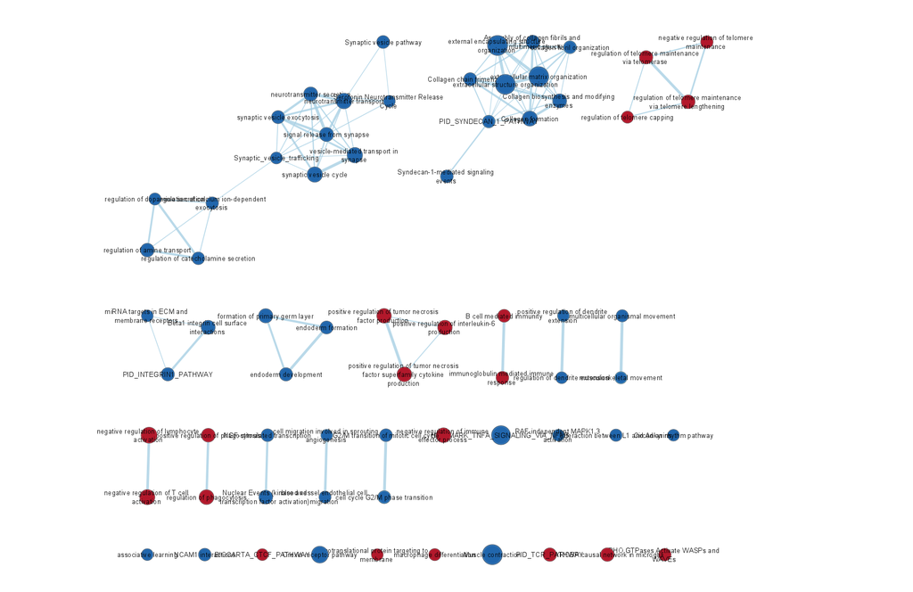

Figure 3. Initial EnrichmentMap network. Each node represents a gene set and is labelled with the name of the gene set, each edge represents a similarity between two gene sets, i.e. how many genes they have in common. The blue nodes represent the genesets enriched in downregulated genes, and the red nodes represent the genesets enriched in upregulated genes.

The network was then manually adjusted in order to be more readable. See Figure 4.

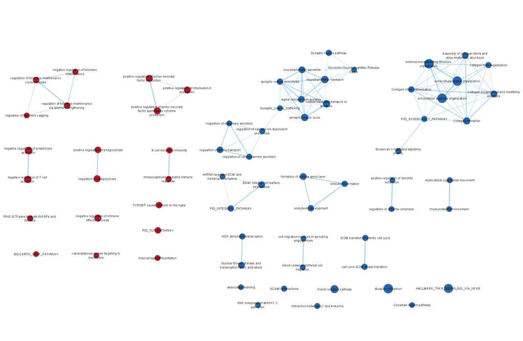

Figure 4. EnrichmentMap network after manual layout adjustment. The red nodes (gene sets upregulated in disease) are to the left side, while the blue nodes (gene sets downregulated in disease) are on the right side. The labels are more clearly visible after manual layout adjustment.

### What parameters were used to annotate the network?

In order to make this EnrichmentMap more meaningful and easily interpretable, the gene sets were grouped together into themes. In the Apps tab in Cytoscape, the AutoAnnotate app was opened, and a new Annotation Set was created with default parameters. The cluster algorithm used was MCL Cluster, Adjacent words was chosen as the label algorithm, and the maximum words per label was left as 3. The Create singleton clusters checkbox was also selected because there was not an excess of nodes and themes, so the network would not have been overcrowded. It was also important to keep these because some of the most enriched gene sets are singletons, and these terms would be lost when collapsing the network in the future if they were not included. In order to make the results more meaningful, the word “Pathway” was added to the list of Excluded words.

The cluster names were manually altered due to the presence of vague and/or uninformative terms. Some words that were removed include “involved,” “primary,” and “cell.” Additionally, the order of words in some terms were rearranged and some were altogether changed to make more sense and be more descriptive.

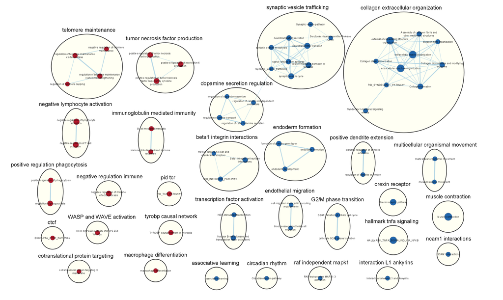

Figure 5. EnrichmentMap network with annotated themes. Pathways are clustered together to represent the major biological theme that is common amongst them.

### Publication Ready Figure

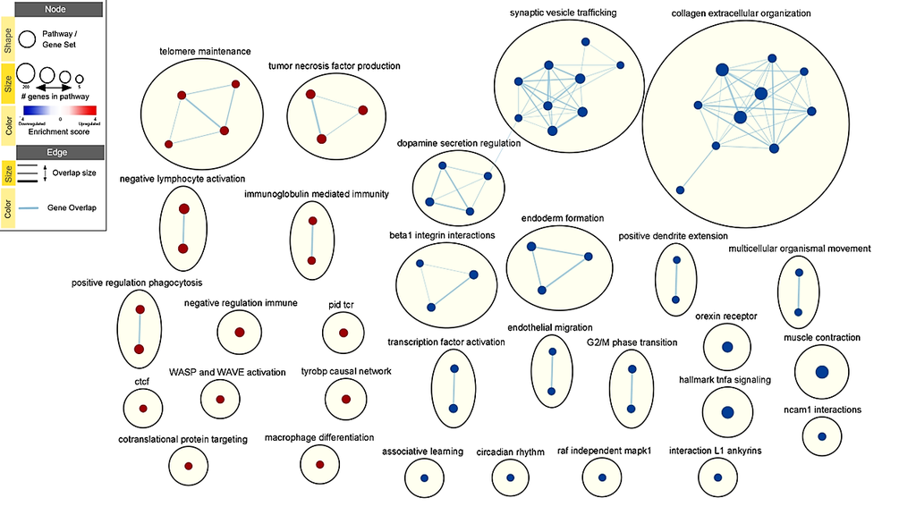

Figure 6. EnrichmentMap network with annotated with major biological themes. Each node in the network represents a gene set/pathway that is enriched in upregulated or downregulated groups of genes. The blue nodes represent the gene sets enriched in genes that are downregulated in disease, and the red nodes represent the gene sets enriched in genes that are upregulated in disease. Each edge represents a similarity between two gene sets, i.e. how many genes they have in common. The size of the gene set determines the size of the node, and the thickness of the edge represents the size of the overlap. The gene sets are clustered together to represent the major biological theme that is common amongst them. The clustered gene sets are found inside the light yellow circles and each circle is labelled at the top with the name of the common theme.

### Collapsing the network to a theme network: What are the major themes present in this analysis? Do they fit with the model? Are there any novel pathways or themes?

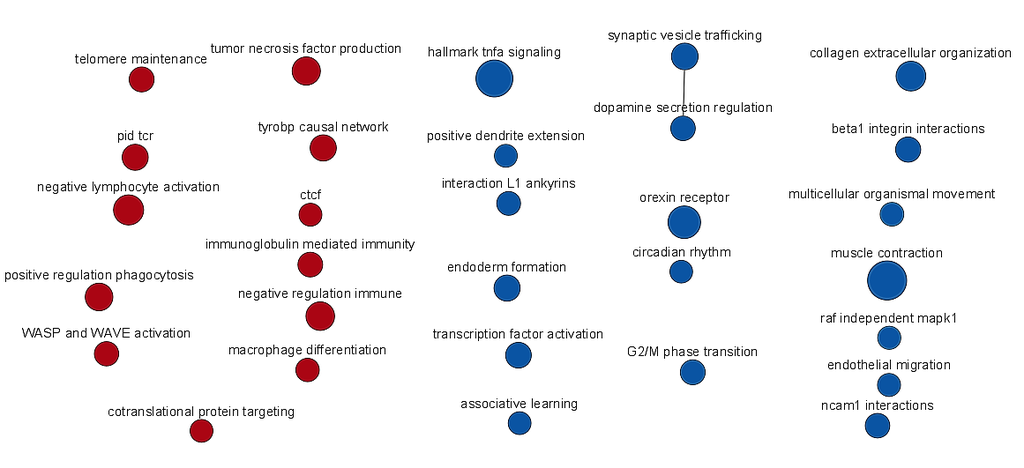

Figure 7. Simplified EnrichmentMap network with major biological themes collapsed into single nodes.

Major themes upregulated in disease:

- Telomere Maintenance
- TNF (Tumor Necrosis Factor) Production

Major themes downregulated in disease:

- Collagen Extracellular Matrix
- Synaptic Vesicle Trafficking
- Dopamine Secretion Regulation

These results fit the disease model as the genes that are supposed to regulate things like neurosignaling through synapses and dopamine synthesis are found to be downregulated. This matches the fact that these functions were discovered to be altered or dysregulated in samples from Schizophrenia patients.

# Discussion

## Evidence to support findings

The goal of the original publication was to examine how hypomethylation of the enhancer within the IGF2 gene may enhance dopamine synthesis associated with major psychosis. The results detailed in the original paper are very similar to the results in this study. A pathway enrichment analysis in the original paper identified that deletion of IGF2 enhancer resulted in alterations in cell development, immune responses, neurodevelopment, and cytoskeletal remodeling. Likewise, this study found that genes that were upregulated in Schizophrenia patient samples are involved in immune responses, while the genes that were downregulated are involved in neuronal cell development. Additionally, in both the initial study and the current one, TNF-alpha signaling via NF-kB was found to be a top-ranking pathway enriched in genes downregulated in disease (Pai et al. 2019).

The most prominent terms in this analysis with support from the initial paper are Dopamine Secretion Regulation and Synaptic Vesicle Trafficking. Analysis of chromatin interactions in the prefrontal cortex revealed that the enhancer at IGF2 targets the promoter of tyrosine hydroxylase (TH), which is a rate-limiting enzyme for the production of dopamine. Dopamine dysregulation in the cortex of schizophrenia patients is known to be involved in the psychotic symptoms of this disease. Reduced DNA methylation at this enhancer was associated with elevated TH protein levels, demonstrating that this enhancer regulates dopamine synthesis (Pai et al. 2019). These prior results are consistent with the gene set enrichment analysis results in this study indicating that the downregulated genes in schizophrenia patient samples are associated with the regulation of dopamine secretion.

After examining the effects of deleting the intergenic Igf2 enhancer in mice, the paper also found that synaptic proteins with the highest differential expression were involved in neurosignaling and structure, and synaptic vesicle release. Genes affecting synaptic plasticity and neurotransmitter release had been found to be dysregulated in the synaptosomal proteome of schizophrenia patients. It was concluded that the loss of the enhancer at Igf2 in mice disrupts synaptic proteins involved in neurotransmission and is associated with psychiatric disease (Pai et al. 2019). Similarly, the downregulated genes in the current study were found to be involved in synaptic vesicle trafficking. Ultimately, this proves that the results in this analysis support conclusions made in the original paper.

Furthermore, these results align with the results from the preceding thresholded gene set enrichment analysis. Several pathways in the two studies are the same, such as those relating to synapse development, immune system, circadian rhythm, and exocytosis. There are some ways that these results differ. One way they differ is that the prior enrichment analysis showed many terms relating to the complement pathway, however, no terms in the non-thresholded analysis were associated with this pathway. Another example is that the results from the non-thresholded analysis showed a lot of association with TNF regulation, whereas this was not prominent in the thresholded enrichment analysis.

## Pathway investigation

### Why this pathway was chosen.

The TYROBP causal network in microglia pathway was chosen as it is the top ranking enriched pathway for upregulated genes in Schizophrenia, yet studies relating this pathway to the disease were hard to find. Interestingly, this same pathway was also found to be enriched in upregulated genes obtained from samples in other neurodegenerative diseases like Alzheimer’s (Ma et al. 2015) and Huntington’s (Creus-Muncunill et al. 2022). Therefore, a more detailed idea of how this pathway relates to Schizophrenia was desired.

### Pathway Diagram

The WikiPathways (Martens et al. 2021) app was installed in Cytoscape, then the pathway “TYROBP causal network in microglia” was imported to be visualized in the desktop application, see Figure 8. To annotate the pathway, a file containing the previously calculated log-fold change and p-value for every gene was imported into Cytoscape as well. Then, for Figures 9 and 10, the node fill colour was mapped based on the log-fold change and p-value, respectively.

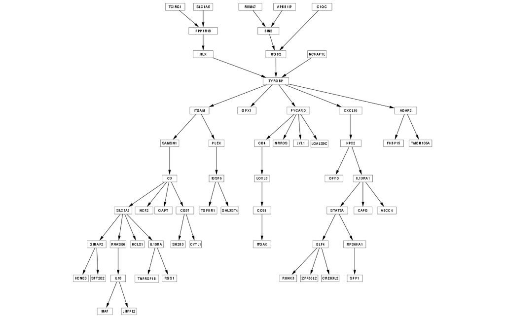

Figure 8. TYROBP causal network in microglia pathway diagram. This diagram shows a series of molecular events, where the nodes are participants in the reactions, in this case genes, and the directed edges represent reactions.

### Annotated Pathway Diagram

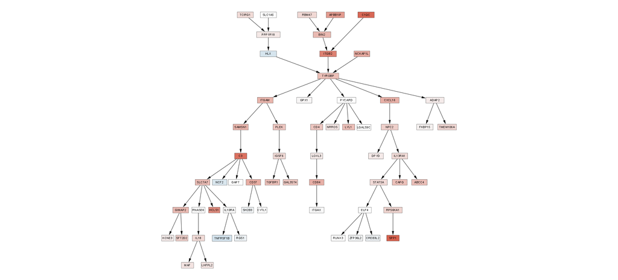

Figure 9. TYROBP causal network in microglia pathway diagram annotated with log-fold change. This diagram shows a series of molecular events, where the nodes are participants in the reactions, in this case genes, and the directed edges represent reactions. The colours of the nodes represents the log-fold change of the genes. The red coloured genes are upregulated in Schizophrenia, and the blue coloured genes are downregulated.

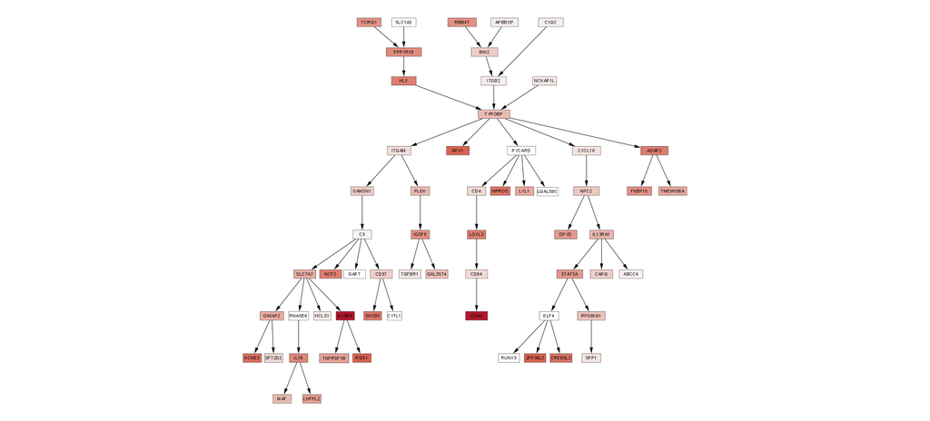

It is evident that most of the genes in this pathway are significantly upregulated. This aligns with the results of the non-thresholded enrichment analysis since the pathway was enriched in upregulated genes.

# Conclusion

Non-thresholded gene set enrichment analysis can provide a lot of important and detailed information about the genes observed in diseases. These observations can help identify pathways that are altered in disease, allowing the potential for developing treatments that target these pathways in a way that they return back to their normal state. In this study, it was found that pathways for synaptic vesicle trafficking, dopamine synthesis, and TYROBP causal networks are altered in Schizophrenia, causing psychotic symptoms. These pathways could be a target for future drug development.

## References

Barrett, Tanya, Stephen E Wilhite, Pierre Ledoux, Carlos Evangelista, Irene F Kim, Maxim Tomashevsky, Kimberly A Marshall, et al. 2012. “NCBI GEO: Archive for Functional Genomics Data Sets—Update.” *Nucleic Acids Research* 41 (D1): D991–95.

Creus-Muncunill, Jordi, Daniele Mattei, Joanna Bons, Angie V Ramirez-Jimenez, B Wade Hamilton, Chuhyon Corwin, Sarah Chowdhury, Birgit Schilling, Lisa Ellerby, and Michelle E Ehrlich. 2022. “Deletion of the Microglial Transmembrane Immune Signaling Adaptor TYROBP Ameliorates Huntington’s Disease Mouse Phenotype.” *bioRxiv*, 2022–02.

Gillespie, Marc, Bijay Jassal, Ralf Stephan, Marija Milacic, Karen Rothfels, Andrea Senff-Ribeiro, Johannes Griss, et al. 2022. “The Reactome Pathway Knowledgebase 2022.” *Nucleic Acids Research* 50 (D1): D687–92.

Hortsch, Michael, Kakanahalli Nagaraj, and Tanja Godenschwege. 2009. “The Interaction Between L1-Type Proteins and Ankyrins-a Master Switch for L1-Type CAM Function.” *Cellular and Molecular Biology Letters* 14 (1): 57–69.

Liberzon, Arthur, Aravind Subramanian, Reid Pinchback, Helga Thorvaldsdóttir, Pablo Tamayo, and Jill P Mesirov. 2011. “Molecular Signatures Database (MSigDB) 3.0.” *Bioinformatics* 27 (12): 1739–40.

Ma, Jing, Teng Jiang, Lan Tan, and Jin-Tai Yu. 2015. “TYROBP in Alzheimer’s Disease.” *Molecular Neurobiology* 51: 820–26.

Martens, Marvin, Ammar Ammar, Anders Riutta, Andra Waagmeester, Denise N Slenter, Kristina Hanspers, Ryan A. Miller, et al. 2021. “WikiPathways: Connecting Communities.” *Nucleic Acids Research* 49 (D1): D613–21.

Nattie, Eugene, and Aihua Li. 2012. “Respiration and Autonomic Regulation and Orexin.” *Progress in Brain Research* 198: 25–46.

Pai, Shraddha, Peipei Li, Bryan Killinger, Lee Marshall, Peixin Jia, Ji Liao, Arturas Petronis, Piroska E Szabó, and Viviane Labrie. 2019. “Differential Methylation of Enhancer at Igf2 Is Associated with Abnormal Dopamine Synthesis in Major Psychosis.” *Nature Communications* 10 (1): 2046.

Reimand, Jüri, Ruth Isserlin, Veronique Voisin, Mike Kucera, Christian Tannus-Lopes, Asha Rostamianfar, Lina Wadi, et al. 2019. “Pathway Enrichment Analysis and Visualization of Omics Data Using g: Profiler, GSEA, Cytoscape and EnrichmentMap.” *Nature Protocols* 14 (2): 482–517.

Shannon, Paul, Andrew Markiel, Owen Ozier, Nitin S Baliga, Jonathan T Wang, Daniel Ramage, Nada Amin, Benno Schwikowski, and Trey Ideker. 2003. “Cytoscape: A Software Environment for Integrated Models of Biomolecular Interaction Networks.” *Genome Research* 13 (11): 2498–2504.

Subramanian, Aravind, Pablo Tamayo, Vamsi K Mootha, Sayan Mukherjee, Benjamin L Ebert, Michael A Gillette, Amanda Paulovich, et al. 2005. “Gene Set Enrichment Analysis: A Knowledge-Based Approach for Interpreting Genome-Wide Expression Profiles.” *Proceedings of the National Academy of Sciences* 102 (43): 15545–50.

Temple Lang, Duncan. 2021. *RCurl: General Network (HTTP/FTP/...) Client Interface for r*. https://CRAN.R-project.org/package=RCurl.